# main_analyses_mcs

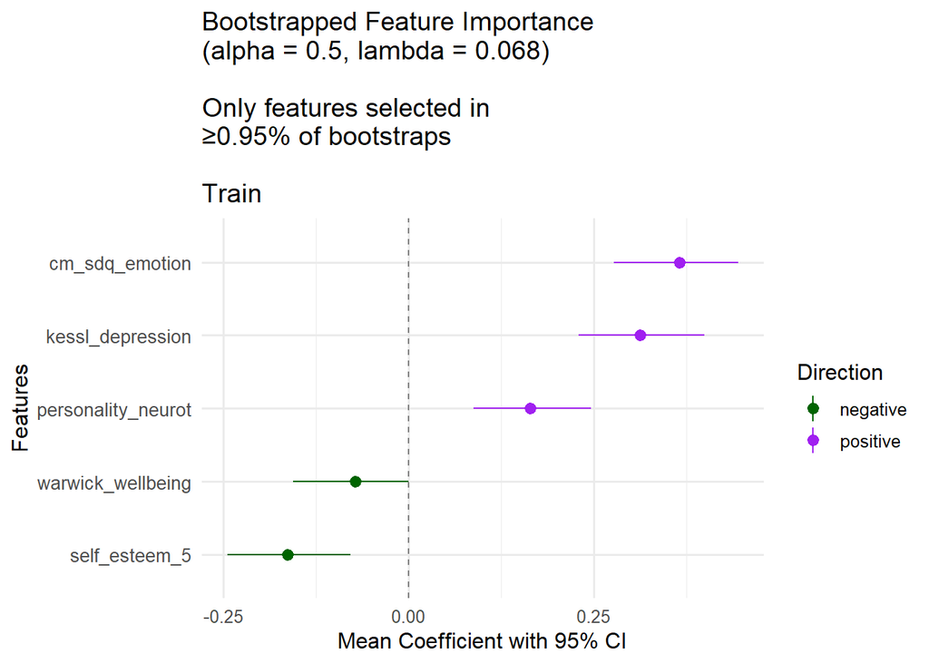

```r
# Print plots
print(results_highSMA_gmm3_C3$train$plot)
```

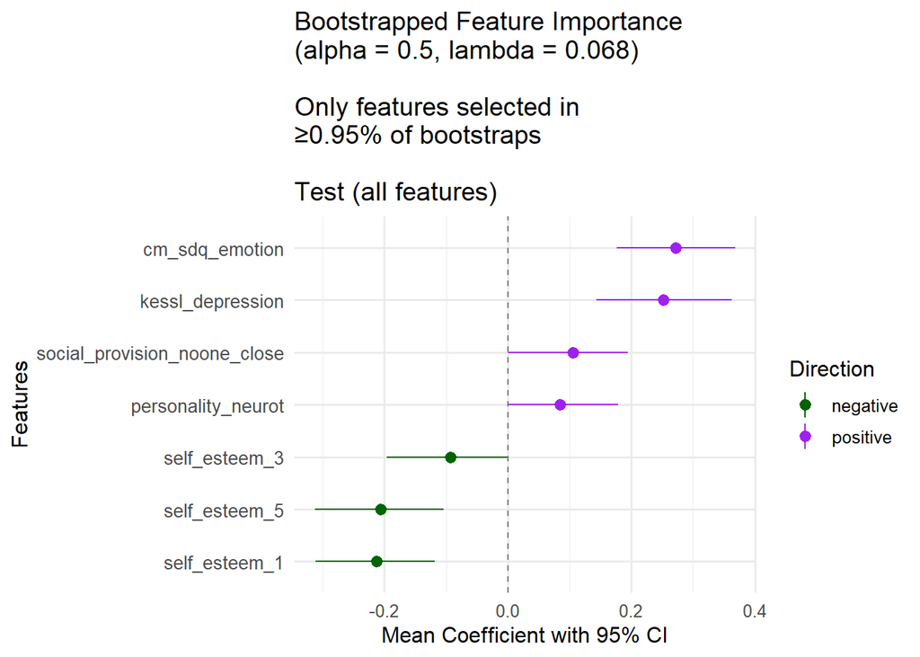

```r
print(results_highSMA_gmm3_C3$test_all$plot)
```

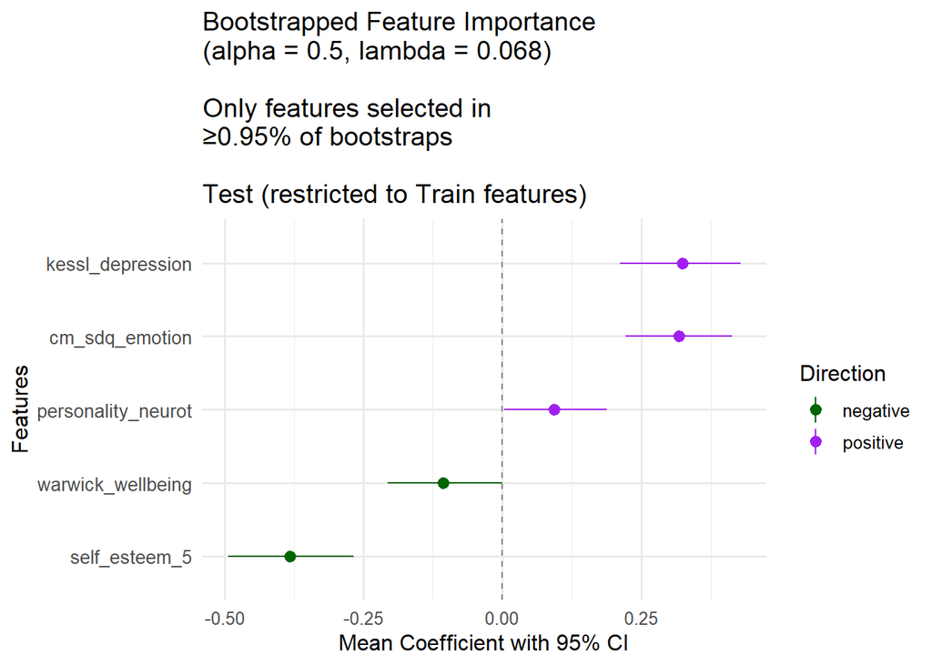

```r
print(results_highSMA_gmm3_C3$test_restricted$plot)
```

```r
####### Make Figure 3 bottom row

Fig03d_plot <- results_highSMA_gmm3_C1$test_restricted$plot +
    scale_x_discrete(
    labels = var_renames
  ) +
    scale_color_manual(
    values = c("positive" = highSMA_cluster_colours[["1"]], "negative" = highSMA_cluster_colours[["1"]])
  ) +
  labs(
    title = ""
  )
Fig03e_plot <- results_highSMA_gmm3_C2$test_restricted$plot +
    scale_x_discrete(
    labels = var_renames
  ) +
    scale_color_manual(
    values = c("positive" = highSMA_cluster_colours[["2"]], "negative" = highSMA_cluster_colours[["2"]])
  ) +
  labs(
    title = ""
  )
Fig03f_plot <- results_highSMA_gmm3_C3$test_restricted$plot +
    scale_x_discrete(
    labels = var_renames
  ) +
    scale_color_manual(
    values = c("positive" = highSMA_cluster_colours[["3"]], "negative" = highSMA_cluster_colours[["3"]])
  ) +
  labs(
    title = ""
  )
ggsave("figures/Fig03d.pdf", plot = Fig03d_plot, bg = "white", width = 7, height = 4.5, units = "in")
ggsave("figures/Fig03e.pdf", plot = Fig03e_plot, bg = "white", width = 7, height = 4.5, units = "in")
ggsave("figures/Fig03f.pdf", plot = Fig03f_plot, bg = "white", width = 7, height = 4.5, units = "in")
```

Now we have done all clustering and regression, we want to compare demographic make-up of each cluster.

Now we explore RQ4 - demographics vs. cluster membership.

Conduct SES PCA to reduce all SES variables to a single dimension. To do this, we i) preprocess the variables (recode gender and ethnicity, then convert all to numerical, then standardise), then ii) exclude all with 30% of data missing, then iii) kNN imputation for the missing variables for the rest, and finally iv) perform PCA.

All these are done separately for the train then test datasets.

First, recode gender and ethnicity.

```r
####### TRAIN

dat_train_highSMA_cluster <- dat_imputed_highSMA_train %>%
  mutate(highSMA_cluster = dat_imputed_highSMA_train_gmm3$classification) %>%
  select(mcsid_cm, highSMA_cluster)

dat_train_demographics_recoded <- dat_imputed_all_train %>%
  left_join(dat_NotImputed, by = "mcsid_cm") %>%
  select(mcsid_cm,
         gender_id,
         birthsex_id,
         eleven_category_ethnicity,
         n_rooms_in_home,
         homelessness,
         income_cm,
         employment_par,
         incomesource_par,
         home_own_par,
         perceived_finances_par,
         household_income_1,
         household_income_2,
         household_income_3,
         household_income_4,
         household_income_5,
         household_income_6) %>%
  mutate(
    all_cluster = dat_imputed_all_train_gmm2$classification
  ) %>%
  left_join(dat_train_highSMA_cluster, by = "mcsid_cm")

### recode gender

dat_train_demographics_recoded <- dat_train_demographics_recoded %>%
  mutate(gender_id_recoded = case_when(
    gender_id == "Male" ~ "Male",
    gender_id == "Female" ~ "Female",
    gender_id %in% c(
      "Non binary",
      "Gender fluid",
      "Androgynous / male and female",
      "Other"
    ) ~ "Other gender",
    gender_id %in% c(
      "Prefer not to say / Refused",
      "Vague irrelevant answer",
      "Don't know"
    ) ~ "Prefer not to say",
    TRUE ~ NA_character_
  ))

### recode ethnicity

dat_train_demographics_recoded <- dat_train_demographics_recoded %>%
  mutate(five_level_ethnicity = case_when(
    eleven_category_ethnicity == "White" ~ "White",
    eleven_category_ethnicity == "Mixed" ~ "Mixed or multiple ethnic groups",
    eleven_category_ethnicity %in% c("Indian", "Pakistani", "Bangladeshi", "Other Asian", "Chinese") ~ "Asian or Asian British",
    eleven_category_ethnicity %in% c("Black Caribbean", "Black African", "Other Black") ~ "Black, Black British, Caribbean or African",
    eleven_category_ethnicity == "Other Ethnic group" ~ "Other Ethnic Group",
    TRUE ~ NA_character_
  ))

####### TEST

dat_test_highSMA_cluster <- dat_imputed_highSMA_test %>%
  mutate(highSMA_cluster = dat_imputed_highSMA_test_gmm3$classification) %>%
  select(mcsid_cm, highSMA_cluster)

dat_test_demographics_recoded <- dat_imputed_all_test %>%
  left_join(dat_NotImputed, by = "mcsid_cm") %>%
  select(mcsid_cm,
         gender_id,
         birthsex_id,
         eleven_category_ethnicity,
         n_rooms_in_home,
         homelessness,
         income_cm,
         employment_par,
         incomesource_par,
         home_own_par,
         perceived_finances_par,
         household_income_1,
         household_income_2,
         household_income_3,
         household_income_4,
         household_income_5,
         household_income_6) %>%
  mutate(
    all_cluster = dat_imputed_all_test_gmm2$classification
  ) %>%
  left_join(dat_test_highSMA_cluster, by = "mcsid_cm")

### recode gender

dat_test_demographics_recoded <- dat_test_demographics_recoded %>%
  mutate(gender_id_recoded = case_when(
    gender_id == "Male" ~ "Male",
    gender_id == "Female" ~ "Female",
    gender_id %in% c(
      "Non binary",
      "Gender fluid",
      "Androgynous / male and female",
      "Other"
    ) ~ "Other gender",
    gender_id %in% c(
      "Prefer not to say / Refused",
      "Vague irrelevant answer",
      "Don't know"
    ) ~ "Prefer not to say",
    TRUE ~ NA_character_
  ))

### recode ethnicity

dat_test_demographics_recoded <- dat_test_demographics_recoded %>%
  mutate(five_level_ethnicity = case_when(
    eleven_category_ethnicity == "White" ~ "White",
    eleven_category_ethnicity == "Mixed" ~ "Mixed or multiple ethnic groups",
    eleven_category_ethnicity %in% c("Indian", "Pakistani", "Bangladeshi", "Other Asian", "Chinese") ~ "Asian or Asian British",
    eleven_category_ethnicity %in% c("Black Caribbean", "Black African", "Other Black") ~ "Black, Black British, Caribbean or African",
    eleven_category_ethnicity == "Other Ethnic group" ~ "Other Ethnic Group",
    TRUE ~ NA_character_
  ))
```

Then, convert all to numeric.

```r
##################################################################################
## First, ordered factors
##################################################################################

####### Define functions to recode income answers to the same scale.
## The variables to convert to numerical are actual income, perceived income and number of rooms.

# Actual income:

# Vectorized function to extract midpoint from income strings
extract_income_midpoint <- Vectorize(function(income_str) {
  if (is.na(income_str)) return(NA_real_)

  # "More than" case
  if (str_detect(income_str, "more than")) {
    num <- str_extract(income_str, "[0-9,]+") %>%
      str_remove_all(",") %>%
      as.numeric()
    return(num + 5000)  # crude lower bound guess
  }

  # "Less than" only (no lower bound given)
  if (str_detect(income_str, "^Annual - less than")) {
    num <- str_extract(income_str, "[0-9,]+") %>%
      str_remove_all(",") %>%
      as.numeric()
    return(num / 2)  # assume midpoint between 0 and this value
  }

  # Standard range (e.g., "from X and less than Y")
  nums <- str_extract_all(income_str, "[0-9,]+")[[1]] %>%
    str_remove_all(",") %>%
    as.numeric()

  if (length(nums) == 2) {
    return(mean(nums))  # midpoint
  } else {
    return(NA_real_)
  }
})

# Vectorized function for time period → annual multiplier
period_multiplier <- Vectorize(function(period_str) {
  if (is.na(period_str)) return(NA_real_)
  period_str <- tolower(period_str)
  case_when(
    str_detect(period_str, "one year|annual") ~ 1,
    str_detect(period_str, "calendar month") ~ 12,
    str_detect(period_str, "two calendar months") ~ 6,
    str_detect(period_str, "four weeks") ~ 13,
    str_detect(period_str, "two weeks") ~ 26,
    str_detect(period_str, "one week") ~ 52,
    str_detect(period_str, "less than one week") ~ 52,
    str_detect(period_str, "six months") ~ 2,
    str_detect(period_str, "nine times a year") ~ 9,
    str_detect(period_str, "one off|lump sum|vague|irrelevant|other period") ~ NA_real_,
    TRUE ~ NA_real_
  )
})

# Apply recoding in pipeline to train and test

##### TRAIN

dat_train_demographics_numeric <- dat_train_demographics_recoded %>%
  mutate(
    # Extract income values from range
    income_1 = extract_income_midpoint(household_income_1),
    income_2 = extract_income_midpoint(household_income_4),

    # Extract time period multipliers
    mult_1 = period_multiplier(household_income_2),
    mult_2 = period_multiplier(household_income_3),
    mult_3 = period_multiplier(household_income_5),
    mult_4 = period_multiplier(household_income_6),

    # Compute estimated annual income
    income_annual_1 = case_when(
      !is.na(income_1) & !is.na(mult_1) ~ income_1 * mult_1,
      !is.na(income_1) & !is.na(mult_2) ~ income_1 * mult_2,
      TRUE ~ NA_real_
    ),

    income_annual_2 = case_when(
      !is.na(income_2) & !is.na(mult_3) ~ income_2 * mult_3,
      !is.na(income_2) & !is.na(mult_4) ~ income_2 * mult_4,
      TRUE ~ NA_real_
    ),

    # Final recoded income: take whichever is available
    household_income_annual_recoded = coalesce(income_annual_1, income_annual_2)
  ) %>%
  # Clean temporary columns
  dplyr::select(-income_1, -income_2, -mult_1, -mult_2, -mult_3, -mult_4,
         -income_annual_1, -income_annual_2)

####### TEST

dat_test_demographics_numeric <- dat_test_demographics_recoded %>%
  mutate(
    # Extract income values from range
    income_1 = extract_income_midpoint(household_income_1),
    income_2 = extract_income_midpoint(household_income_4),

    # Extract time period multipliers
    mult_1 = period_multiplier(household_income_2),
    mult_2 = period_multiplier(household_income_3),
    mult_3 = period_multiplier(household_income_5),
    mult_4 = period_multiplier(household_income_6),

    # Compute estimated annual income
    income_annual_1 = case_when(
      !is.na(income_1) & !is.na(mult_1) ~ income_1 * mult_1,
      !is.na(income_1) & !is.na(mult_2) ~ income_1 * mult_2,
      TRUE ~ NA_real_
    ),

    income_annual_2 = case_when(
      !is.na(income_2) & !is.na(mult_3) ~ income_2 * mult_3,
      !is.na(income_2) & !is.na(mult_4) ~ income_2 * mult_4,
      TRUE ~ NA_real_
    ),

    # Final recoded income: take whichever is available
    household_income_annual_recoded = coalesce(income_annual_1, income_annual_2)
  ) %>%
  # Clean temporary columns
  dplyr::select(-income_1, -income_2, -mult_1, -mult_2, -mult_3, -mult_4,
         -income_annual_1, -income_annual_2)



# Perceived income and Nrooms:

perceied_fin_levels <- c(
   "Finding it very difficult" ,
   "Finding it quite difficult",
    "Just about getting by" ,
   "Doing alright"    ,
   "Living comfortably"
)

### TRAIN

dat_train_demographics_numeric$perceived_finances_par     <- factor(dat_train_demographics_numeric$perceived_finances_par, levels = perceied_fin_levels, ordered = TRUE)
dat_train_demographics_numeric$perceived_finances_par_num <- as.numeric(dat_train_demographics_numeric$perceived_finances_par)

dat_train_demographics_numeric <- dat_train_demographics_numeric %>%
  mutate(
    n_rooms_num = case_when(
      str_detect(n_rooms_in_home, "10\\+") ~ 10,
      TRUE ~ str_extract(n_rooms_in_home, "\\d+") %>% as.numeric()
    )
  )


### TEST


dat_test_demographics_numeric$perceived_finances_par <- factor(dat_test_demographics_numeric$perceived_finances_par, levels = perceied_fin_levels, ordered = TRUE)
dat_test_demographics_numeric$perceived_finances_par_num <- as.numeric(dat_test_demographics_numeric$perceived_finances_par)

dat_test_demographics_numeric <- dat_test_demographics_numeric %>%
  mutate(
    n_rooms_num = case_when(
      str_detect(n_rooms_in_home, "10\\+") ~ 10,
      TRUE ~ str_extract(n_rooms_in_home, "\\d+") %>% as.numeric()
    )
  )
```

Now exclude those with over 30% of variables missing.

```r
# select only the SES vars

dat_train_SES <- dat_train_demographics_numeric %>%
  dplyr::select(
    mcsid_cm,
    n_rooms_num,
    homelessness,
    income_cm,
    employment_par,
    incomesource_par,
    home_own_par,
    perceived_finances_par_num,
    household_income_annual_recoded
  ) %>%
  mutate(
    valid_row = rowSums(!is.na(across(-mcsid_cm))) / (ncol(across(-mcsid_cm))) > 0.7
    )

dat_test_SES <- dat_test_demographics_numeric %>%
  dplyr::select(
    mcsid_cm,
    n_rooms_num,
    homelessness,
    income_cm,
    employment_par,
    incomesource_par,
    home_own_par,
    perceived_finances_par_num,
    household_income_annual_recoded
  )%>%
  mutate(
    valid_row = rowSums(!is.na(across(-mcsid_cm))) / (ncol(across(-mcsid_cm))) > 0.7
    )

dat_train_SES_retain <- dat_train_SES %>%
  filter(valid_row == TRUE) %>%
  select(-valid_row)


dat_test_SES_retain <- dat_test_SES %>%
  filter(valid_row == TRUE) %>%
  select(-valid_row)


print(str_c("MCSID_CM included in train: ", length(unique(dat_train_SES_retain$mcsid_cm)), ", MCSID_CM excluded: ", sum(dat_train_SES$valid_row == FALSE)))
```

```
## [1] "MCSID_CM included in train: 3377, MCSID_CM excluded: 591"
```

```r
print(str_c("MCSID_CM included in test: ", length(unique(dat_test_SES_retain$mcsid_cm)), ", MCSID_CM excluded: ", sum(dat_test_SES$valid_row == FALSE)))
```

```
## [1] "MCSID_CM included in test: 2301, MCSID_CM excluded: 405"
```

Scale numerical variables before adding

```r
dat_train_SES_scaled <- dat_train_SES_retain
dat_test_SES_scaled  <- dat_test_SES_retain

######## Scale

dat_train_SES_scaled$household_income_annual_recoded  <- scale(dat_train_SES_scaled$household_income_annual_recoded)
dat_train_SES_scaled$perceived_finances_par_num       <- scale(dat_train_SES_scaled$perceived_finances_par_num)
dat_train_SES_scaled$n_rooms_num                      <- scale(dat_train_SES_scaled$n_rooms_num)

dat_test_SES_scaled$household_income_annual_recoded   <- scale(dat_test_SES_scaled$household_income_annual_recoded)
dat_test_SES_scaled$perceived_finances_par_num        <- scale(dat_test_SES_scaled$perceived_finances_par_num)
dat_test_SES_scaled$n_rooms_num                       <- scale(dat_test_SES_scaled$n_rooms_num)
```

Now create dummy variables for the unordered factors.

```r
##################################################################################
## Now, unordered factors
##################################################################################

create_dummy_variables <- function(df) {

  # Identify character columns, excluding 'mcsid_cm'
  char_cols <- setdiff(names(df)[sapply(df, is.character)], "mcsid_cm")

  # Convert those character columns to factors (to use fct_inorder)
  df <- df %>%
    mutate(across(all_of(char_cols), ~ as.factor(.x))) %>%
    # Change factor order so first dummy removed corresponds to most frequent level
    mutate(across(all_of(char_cols), fct_inorder))

  # Create dummy variables for these now-factor columns
  dat_dummies <- dummy_cols(
    df,
    select_columns = char_cols,
    remove_selected_columns = TRUE,
    remove_first_dummy = TRUE,
    ignore_na = TRUE
  )

  # Replace spaces in column names with underscores
  names(dat_dummies) <- gsub(" ", "_", names(dat_dummies))

  return(dat_dummies)
}


# Apply the function
dat_train_SES_dummies <- create_dummy_variables(dat_train_SES_scaled)
dat_test_SES_dummies  <- create_dummy_variables(dat_test_SES_scaled)
```

Now perform imputation for the remaining variables.

```r
##### TRAIN
dat_train_SES_imputed <- kNN(dat_train_SES_dummies,
                   variable = colnames(select(dat_train_SES_dummies, -mcsid_cm)),
                   k        = 25,
                   dist_var = colnames(select(dat_train_SES_dummies, -mcsid_cm))
)
# remove the new columns which say if it was imputed
dat_train_SES_imputed <- dat_train_SES_imputed[ , !grepl("_imp$", names(dat_train_SES_imputed))]


dat_test_SES_imputed <- kNN(dat_test_SES_dummies,
                   variable = colnames(select(dat_test_SES_dummies, -mcsid_cm)),
                   k        = 25,
                   dist_var = colnames(select(dat_test_SES_dummies, -mcsid_cm))
)
# remove the new columns which say if it was imputed
dat_test_SES_imputed <- dat_test_SES_imputed[ , !grepl("_imp$", names(dat_test_SES_imputed))]
```

Now perform PCA.

```r
####################################################################
#### TRAIN
####################################################################

# Select numeric columns excluding cluster columns
pca_train_data <- dat_train_SES_imputed %>%
  select(-mcsid_cm)

# Now run PCA on clean data
pca_train <- princomp(pca_train_data)
summary(pca_train)
```

```
## Importance of components:
##                           Comp.1    Comp.2    Comp.3     Comp.4     Comp.5
## Standard deviation     1.2463151 0.8422677 0.7496034 0.56121632 0.37305664
## Proportion of Variance 0.4099234 0.1872178 0.1482894 0.08312038 0.03672793
## Cumulative Proportion  0.4099234 0.5971412 0.7454306 0.82855096 0.86527889
##                            Comp.6     Comp.7     Comp.8     Comp.9    Comp.10
## Standard deviation     0.35159173 0.29338601 0.28713781 0.26286502 0.22010028
## Proportion of Variance 0.03262302 0.02271568 0.02175844 0.01823528 0.01278463
## Cumulative Proportion  0.89790192 0.92061760 0.94237603 0.96061132 0.97339595
##                            Comp.11     Comp.12     Comp.13     Comp.14
## Standard deviation     0.150950415 0.140395762 0.103186137 0.092447515
## Proportion of Variance 0.006013337 0.005201815 0.002809892 0.002255472
## Cumulative Proportion  0.979409283 0.984611098 0.987420990 0.989676462
##                            Comp.15     Comp.16     Comp.17     Comp.18
## Standard deviation     0.078643756 0.077344793 0.074489473 0.073292334
## Proportion of Variance 0.001632208 0.001578734 0.001464322 0.001417634
## Cumulative Proportion  0.991308670 0.992887404 0.994351727 0.995769360
##                            Comp.19     Comp.20     Comp.21     Comp.22
## Standard deviation     0.071896693 0.064369880 0.056502100 0.048529426
## Proportion of Variance 0.001364158 0.001093484 0.000842512 0.000621523
## Cumulative Proportion  0.997133518 0.998227002 0.999069514 0.999691037
##                             Comp.23
## Standard deviation     0.0342160306
## Proportion of Variance 0.0003089628
## Cumulative Proportion  1.0000000000
```

```r
# Step 1: Extract scores on first principal component
pc1_scores_train <- pca_train$scores[, 1]

# Now, assign the PC1 scores into the main dataset

dat_train_SES_dummies_PC1 <- dat_train_SES_dummies %>%
  mutate(SES_PC1 = pc1_scores_train) %>%
  dplyr::select(mcsid_cm, SES_PC1)

dat_train_demographics_SES <- dat_train_demographics_recoded %>%
  left_join(dat_train_SES_dummies_PC1, by = "mcsid_cm")
dat_train_SES_dummies$SES_PC1 <- pc1_scores_train

####################################################################
#### TEST
####################################################################

# Select numeric columns excluding cluster columns
pca_test_data <- dat_test_SES_imputed %>%
  select(-mcsid_cm)

# Now run PCA on clean data
pca_test <- princomp(pca_test_data)
summary(pca_test)
```

```
## Importance of components:
##                           Comp.1    Comp.2    Comp.3     Comp.4     Comp.5
## Standard deviation     1.2097143 0.8538808 0.7908115 0.38547048 0.38008207
## Proportion of Variance 0.4025494 0.2005618 0.1720282 0.04087294 0.03973822
## Cumulative Proportion  0.4025494 0.6031112 0.7751394 0.81601230 0.85575052
##                            Comp.6     Comp.7     Comp.8     Comp.9    Comp.10
## Standard deviation     0.35990285 0.29881298 0.27386709 0.26493261 0.21400686
## Proportion of Variance 0.03563069 0.02456137 0.02063162 0.01930743 0.01259821
## Cumulative Proportion  0.89138121 0.91594257 0.93657419 0.95588162 0.96847983
##                           Comp.11     Comp.12     Comp.13     Comp.14
## Standard deviation     0.19992929 0.137248745 0.102815213 0.093045136
## Proportion of Variance 0.01099528 0.005181677 0.002907826 0.002381447
## Cumulative Proportion  0.97947512 0.984656793 0.987564618 0.989946066
##                            Comp.15     Comp.16     Comp.17     Comp.18
## Standard deviation     0.082183830 0.080936888 0.071266825 0.070870011
## Proportion of Variance 0.001857917 0.001801966 0.001397103 0.001381588
## Cumulative Proportion  0.991803983 0.993605949 0.995003052 0.996384640
##                            Comp.19     Comp.20      Comp.21      Comp.22
## Standard deviation     0.068567798 0.067461865 0.0464858299 0.0360024855
## Proportion of Variance 0.001293284 0.001251902 0.0005944219 0.0003565485
## Cumulative Proportion  0.997677924 0.998929826 0.9995242479 0.9998807964
##                             Comp.23
## Standard deviation     0.0208169890
## Proportion of Variance 0.0001192036
## Cumulative Proportion  1.0000000000
```

```r
# Step 1: Extract scores on first principal component
pc1_scores_test <- pca_test$scores[, 1]

# Now, assign the PC1 scores into the main dataset

dat_test_SES_dummies_PC1 <- dat_test_SES_dummies %>%
  mutate(SES_PC1 = pc1_scores_test) %>%
  dplyr::select(mcsid_cm, SES_PC1)

dat_test_demographics_SES <- dat_test_demographics_recoded %>%
  left_join(dat_test_SES_dummies_PC1, by = "mcsid_cm")
dat_test_SES_dummies$SES_PC1 <- pc1_scores_test
```

Now make the demographics tables for the clusters.

```r
####################################################################
#### MAKE TABLES

 # Row function:
make_prop_N_row <- function(df, cluster_var, cat_var) {

  tab      <- table(df[[cat_var]], df[[cluster_var]])
  prop_tab <- prop.table(tab, margin = 2)  # column-wise proportions

  counts <- as.data.frame.matrix(tab)
  props  <- round(as.data.frame.matrix(prop_tab), 3)

  row_final <- data.frame(Category = rownames(counts))

  for (k in seq_len(ncol(counts))) {
    row_final[[paste0("C", k, "_N")]]    <- counts[, k]
    row_final[[paste0("C", k, "_prop")]] <- props[, k]
    }

  return(row_final)

}

make_SES_row <- function(df, cluster_var, ses_var) {

  # Count number of unique groups
  n_groups <- df %>% dplyr::pull(!!rlang::sym(cluster_var)) %>% unique() %>% length()

  # Compute means per group
  stats <- df %>%
    dplyr::group_by(!!rlang::sym(cluster_var)) %>%
    dplyr::summarise(
      n_val    = dplyr::n(),
      mean_val = mean(!!rlang::sym(ses_var), na.rm = TRUE) %>% round(3),
      .groups = "drop"
    ) %>%
    dplyr::arrange(!!rlang::sym(cluster_var))

  row_final <- data.frame(Category = "SES PC1")

  # Add group means dynamically
  for (i in seq_len(nrow(stats))) {
    row_final[[paste0("n_C", i)]] <- stats$n_val[i]
    row_final[[paste0("C", i)]]   <- stats$mean_val[i]
  }

  return(row_final)
}

summary_all_cluster_train <- bind_rows(
  make_prop_N_row(dat_train_demographics_SES, "all_cluster", "gender_id_recoded"),
  make_prop_N_row(dat_train_demographics_SES, "all_cluster", "five_level_ethnicity"),
  make_SES_row(dat_train_demographics_SES, "all_cluster", "SES_PC1")
)

dat_train_demographics_SES_highSMA <- filter(dat_train_demographics_SES, !is.na(highSMA_cluster))
summary_highSMA_cluster_train <- bind_rows(
  make_prop_N_row(dat_train_demographics_SES, "highSMA_cluster", "gender_id_recoded"),
  make_prop_N_row(dat_train_demographics_SES, "highSMA_cluster", "five_level_ethnicity"),
  make_SES_row(dat_train_demographics_SES, "highSMA_cluster", "SES_PC1")
)

summary_all_cluster_test <- bind_rows(
  make_prop_N_row(dat_test_demographics_SES, "all_cluster", "gender_id_recoded"),
  make_prop_N_row(dat_test_demographics_SES, "all_cluster", "five_level_ethnicity"),
  make_SES_row(dat_test_demographics_SES, "all_cluster", "SES_PC1")
)

dat_test_demographics_SES_highSMA <- filter(dat_test_demographics_SES, !is.na(highSMA_cluster))
summary_highSMA_cluster_test <- bind_rows(
  make_prop_N_row(dat_test_demographics_SES_highSMA, "highSMA_cluster", "gender_id_recoded"),
  make_prop_N_row(dat_test_demographics_SES_highSMA, "highSMA_cluster", "five_level_ethnicity"),
  make_SES_row(dat_test_demographics_SES_highSMA, "highSMA_cluster", "SES_PC1")
)

####################################################################
#### Now do stats.
####################################################################

# Helper function to compute chi-square table

compute_chisq <- function(df, cluster_var, cat_var) {
  tab      <- table(df[[cat_var]], df[[cluster_var]])
  prop_tab <- prop.table(tab, margin = 2)  # column-wise proportions
  counts   <- as.data.frame.matrix(tab)
  props    <- as.data.frame.matrix(prop_tab)

  chisq.test(tab)
}

# High SMA, Gender v. cluster:
print(
  compute_chisq(dat_test_demographics_SES_highSMA, "highSMA_cluster", "gender_id_recoded"))
```

```
##
##  Pearson's Chi-squared test
##
## data:  tab
## X-squared = 75.573, df = 6, p-value = 2.926e-14
```

```r
# Post hoc tests:
C1_N_female <- filter(summary_highSMA_cluster_test, Category == "Female")$C1_N
C2_N_female <- filter(summary_highSMA_cluster_test, Category == "Female")$C2_N
C3_N_female <- filter(summary_highSMA_cluster_test, Category == "Female")$C3_N

C1_N_total_gender  <- sum(make_prop_N_row(dat_test_demographics_SES_highSMA, "highSMA_cluster", "gender_id_recoded")$C1_N)
C2_N_total_gender  <- sum(make_prop_N_row(dat_test_demographics_SES_highSMA, "highSMA_cluster", "gender_id_recoded")$C2_N)
C3_N_total_gender  <- sum(make_prop_N_row(dat_test_demographics_SES_highSMA, "highSMA_cluster", "gender_id_recoded")$C3_N)

GenderC1C2 <- matrix(
  c(C1_N_female, C1_N_total_gender - C1_N_female,
    C2_N_female, C2_N_total_gender - C2_N_female),
  nrow = 2,
  byrow = TRUE
)
chisq.test(GenderC1C2)
```

```
##
##  Pearson's Chi-squared test with Yates' continuity correction
##
## data:  GenderC1C2
## X-squared = 32.611, df = 1, p-value = 1.126e-08
```

```r
GenderC1C3 <- matrix(
  c(C1_N_female, C1_N_total_gender - C1_N_female,
    C3_N_female, C3_N_total_gender - C3_N_female),
  nrow = 2,
  byrow = TRUE
)
chisq.test(GenderC1C3)
```

```
##
##  Pearson's Chi-squared test with Yates' continuity correction
##
## data:  GenderC1C3
## X-squared = 11.175, df = 1, p-value = 0.0008291
```

```r
GenderC2C3 <- matrix(
  c(C2_N_female, C2_N_total_gender - C2_N_female,
    C3_N_female, C3_N_total_gender - C3_N_female),
  nrow = 2,
  byrow = TRUE
)
chisq.test(GenderC2C3)
```

```
##
##  Pearson's Chi-squared test with Yates' continuity correction
##
## data:  GenderC2C3
## X-squared = 49.507, df = 1, p-value = 1.977e-12
```

```r
GenderC1C2 <- matrix(
  c(C1_N_female, C1_N_total_gender - C1_N_female,
    C2_N_female, C2_N_total_gender - C2_N_female),
  nrow = 2,
  byrow = TRUE
)
chisq.test(GenderC1C2)
```

```
##
##  Pearson's Chi-squared test with Yates' continuity correction
##
## data:  GenderC1C2
## X-squared = 32.611, df = 1, p-value = 1.126e-08
```

```r
# High SMA, Ethnicity v. cluster:
print(
  compute_chisq(dat_test_demographics_SES_highSMA, "highSMA_cluster", "five_level_ethnicity"))
```

```
##
##  Pearson's Chi-squared test
##
## data:  tab
## X-squared = 13.927, df = 8, p-value = 0.08369
```

```r
# Not significant so no post-hoc tests

# High SMA, SES PC1 v. cluster:
SES_anova <- aov(dat_test_demographics_SES_highSMA[["SES_PC1"]] ~ as.factor(dat_test_demographics_SES_highSMA[["highSMA_cluster"]]), data = dat_test_demographics_SES_highSMA)
summary(SES_anova)
```

```
##                                                                     Df Sum Sq
## as.factor(dat_test_demographics_SES_highSMA[["highSMA_cluster"]])    2   13.6
## Residuals                                                         1085 1558.4
##                                                                   Mean Sq
## as.factor(dat_test_demographics_SES_highSMA[["highSMA_cluster"]])   6.800
## Residuals                                                           1.436
##                                                                   F value
## as.factor(dat_test_demographics_SES_highSMA[["highSMA_cluster"]])   4.734
## Residuals
##                                                                    Pr(>F)
## as.factor(dat_test_demographics_SES_highSMA[["highSMA_cluster"]]) 0.00897 **
## Residuals
## ---
## Signif. codes:  0 '***' 0.001 '**' 0.01 '*' 0.05 '.' 0.1 ' ' 1
## 204 observations deleted due to missingness
```

```r
# Post hoc tests:
TukeyHSD(SES_anova)
```

```
##   Tukey multiple comparisons of means
##     95% family-wise confidence level
##
## Fit: aov(formula = dat_test_demographics_SES_highSMA[["SES_PC1"]] ~ as.factor(dat_test_demographics_SES_highSMA[["highSMA_cluster"]]), data = dat_test_demographics_SES_highSMA)
##
## $`as.factor(dat_test_demographics_SES_highSMA[["highSMA_cluster"]])`
##           diff        lwr         upr     p adj
## 2-1 -0.1848423 -0.4696283  0.09994378 0.2803463
## 3-1 -0.2886786 -0.5249523 -0.05240478 0.0117376
## 3-2 -0.1038363 -0.4462869  0.23861429 0.7566691
```

```r
write.csv(summary_all_cluster_train, str_c( "summary_tables/", format(Sys.time(), "%Y%m%d_%H%M"), "summary_all_cluster_train.csv"))
write.csv(summary_highSMA_cluster_train, str_c( "summary_tables/", format(Sys.time(), "%Y%m%d_%H%M"), "summary_highSMA_cluster_train.csv"))

write.csv(summary_all_cluster_test, str_c( "summary_tables/", format(Sys.time(), "%Y%m%d_%H%M"), "summary_all_cluster_test.csv"))
write.csv(summary_highSMA_cluster_test, str_c( "summary_tables/", format(Sys.time(), "%Y%m%d_%H%M"), "summary_highSMA_cluster_test.csv"))
```

```r
# convert smHrs into numeric
smHrs_levels <- c("None",
                  "Less than half an hour",
                  "Half an hour to less than 1 hour",
                  "1 hour to less than 2 hours",
                  "2 hours to less than 3 hours",
                  "3 hours to less than 5 hours",
                  "5 hours to less than 7 hours",
                  "7 hours to less than 10 hours",
                  "10 hours or more")

# Define numeric values
smHrs_numeric <- c(0,
                   0.25,
                   1.5,
                   2.5,
                   4,
                   6,
                   8.5,
                   10)

prepare_smHrs_data <- function(dat_imputed_highSMA, dat_imputed_lowSMA, dat_NotImputed, classification_obj_highSMA, classification_obj_lowSMA, group = "train") {

  # High SMA group with GMM clusters
  dat_high <- dat_imputed_highSMA %>%
    left_join(dat_NotImputed, by = "mcsid_cm") %>%
    dplyr::select(mcsid_cm, sma, sm_hrs, kessl_depression.y,  warwick_wellbeing.y, self_control.y) %>%
    mutate(
      sm_hrs         = factor(sm_hrs, levels = smHrs_levels, ordered = TRUE),
      sm_hrs_Numeric = smHrs_numeric[as.numeric(sm_hrs)],
      cluster        = str_c("highSMA", as.character(classification_obj_highSMA$classification)),
      sma            = factor(sma, levels = sma_levels, ordered = TRUE),
      dataset        = group
    )

  dat_low <- dat_imputed_lowSMA %>%
    left_join(dat_NotImputed, by = "mcsid_cm") %>%
    left_join(classification_obj_lowSMA, by = "mcsid_cm") %>%
    dplyr::select(mcsid_cm, sma, sm_hrs, kessl_depression.y, warwick_wellbeing.y, self_control.y, classification) %>%
    mutate(
      sm_hrs         = factor(sm_hrs, levels = smHrs_levels, ordered = TRUE),
      sm_hrs_Numeric = smHrs_numeric[as.numeric(sm_hrs)],
     # cluster        = str_c("lowSMA", as.character(classification)),
      cluster        = "lowSMA",
      sma            = factor(sma, levels = sma_levels, ordered = TRUE),
      dataset        = group
    )

  dplyr::bind_rows(dat_high, dat_low)
}

  # Low SMA group
dat_imputed_all_train_cluster <- dat_imputed_all_train %>%
    mutate(classification = dat_imputed_all_train_gmm2$classification) %>%
    select(mcsid_cm, classification)
  # Low SMA group
dat_imputed_all_test_cluster <- dat_imputed_all_test %>%
    mutate(classification = dat_imputed_all_test_gmm2$classification) %>%
    select(mcsid_cm, classification)


dat_train_smHrs <- prepare_smHrs_data(
  dat_imputed_highSMA_train,
  dat_imputed_lowSMA_train,
  dat_NotImputed,
  dat_imputed_highSMA_train_gmm3,
  dat_imputed_all_train_cluster,
  group = "Train"
)

dat_test_smHrs <- prepare_smHrs_data(
  dat_imputed_highSMA_test,
  dat_imputed_lowSMA_test,
  dat_NotImputed,
  dat_imputed_highSMA_test_gmm3,
  dat_imputed_all_test_cluster,
  group = "Test"
)

# Combine both
dat_all_smHrs <- dplyr::bind_rows(dat_train_smHrs, dat_test_smHrs)
dat_all_smHrs$dataset <- factor(dat_all_smHrs$dataset, levels = rev(levels(factor(dat_all_smHrs$dataset))))
```

Now we compare each variable between the clusters (Figure 4).

Figure 4a: Comparing self-reported addiction between clusters.

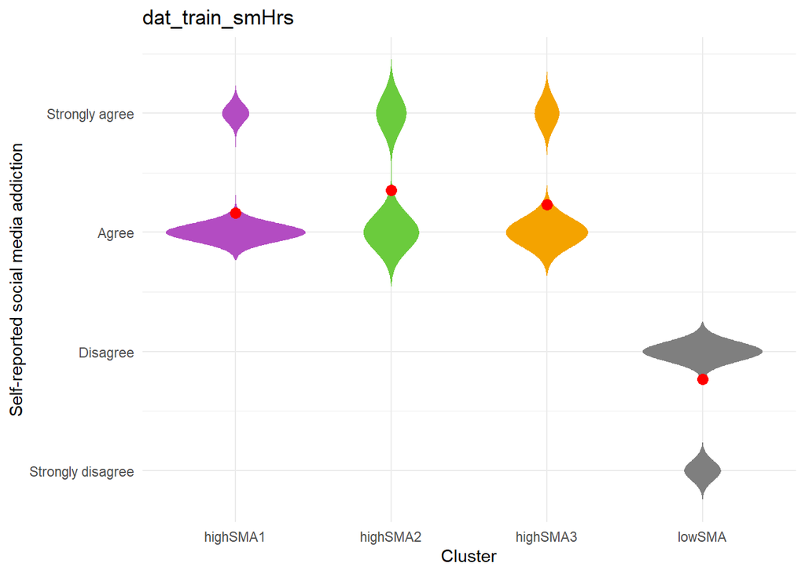

```r
plot_violin_with_title <- function(data) {
  dataset_name <- deparse(substitute(data))

  means <- data %>%
    group_by(cluster) %>%
    summarize(mean_sma = mean(as.numeric(sma)))

  ggplot(data, aes(x = as.factor(cluster), y = as.numeric(sma), fill = as.factor(cluster))) +
    geom_violin(trim = FALSE, color = NA) +

    geom_point(data = means,
               aes(x = as.factor(cluster), y = mean_sma),
               inherit.aes = FALSE,
               color = "red", size = 3) +

    scale_x_discrete(name = "Cluster") +
    scale_y_continuous(
      name = "Self-reported social media addiction",
      breaks = sort(unique(as.numeric(data$sma))),
      labels = levels(data$sma)
    ) + scale_fill_manual(
    values = c(
      "highSMA1" = "#B34CC2",
      "highSMA2" = "#6BCB3D",
      "highSMA3" = "#F4A300"
    )) +

    labs(title = dataset_name) +
    theme_minimal() +
    theme(legend.position = "none")
}

plot_violin_with_title(dat_train_smHrs)
```

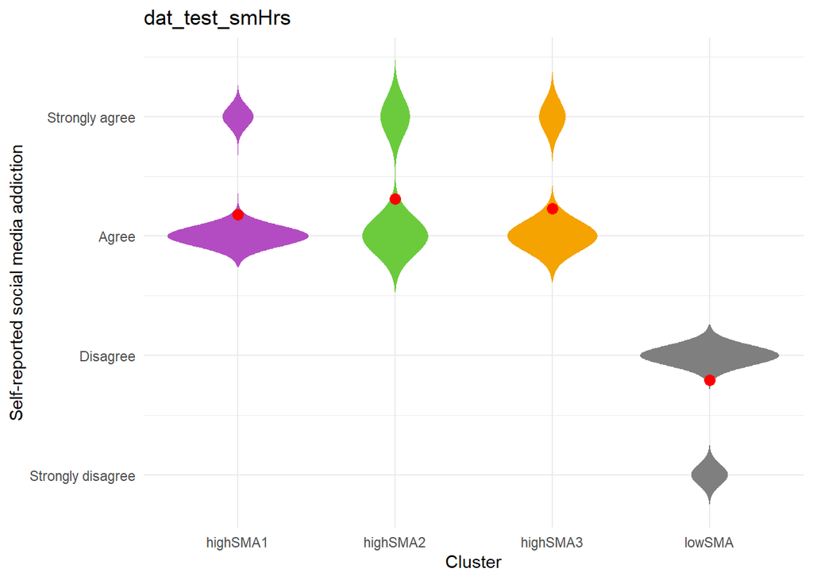

```r
plot_violin_with_title(dat_test_smHrs)
```

```r
Fig04a_plot <- plot_violin_with_title(dat_test_smHrs)
ggsave("figures/Fig04a.pdf", plot = Fig04a_plot, bg = "white", width = 7, height = 4.5, units = "in")


####################################################################
#### Now do stats.
####################################################################


dat_c1_c2 <- filter(dat_test_smHrs, cluster == "highSMA1" | cluster == "highSMA2")
dat_c1_c3 <- filter(dat_test_smHrs, cluster == "highSMA1" | cluster == "highSMA3")
dat_c2_c3 <- filter(dat_test_smHrs, cluster == "highSMA2" | cluster == "highSMA3")

chisq.test(table(dat_c1_c2$cluster, dat_c1_c2$sma)[rowSums(table(dat_c1_c2$cluster, dat_c1_c2$sma)) != 0, colSums(table(dat_c1_c2$cluster, dat_c1_c2$sma)) != 0])
```

```
##
##  Pearson's Chi-squared test with Yates' continuity correction
##
## data:  table(dat_c1_c2$cluster, dat_c1_c2$sma)[rowSums(table(dat_c1_c2$cluster,     dat_c1_c2$sma)) != 0, colSums(table(dat_c1_c2$cluster, dat_c1_c2$sma)) !=     0]
## X-squared = 11.059, df = 1, p-value = 0.0008826
```

```r
chisq.test(table(dat_c1_c3$cluster, dat_c1_c3$sma)[rowSums(table(dat_c1_c3$cluster, dat_c1_c3$sma)) != 0, colSums(table(dat_c1_c3$cluster, dat_c1_c3$sma)) != 0])
```

```
##
##  Pearson's Chi-squared test with Yates' continuity correction
##
## data:  table(dat_c1_c3$cluster, dat_c1_c3$sma)[rowSums(table(dat_c1_c3$cluster,     dat_c1_c3$sma)) != 0, colSums(table(dat_c1_c3$cluster, dat_c1_c3$sma)) !=     0]
## X-squared = 2.2346, df = 1, p-value = 0.135
```

```r
chisq.test(table(dat_c2_c3$cluster, dat_c2_c3$sma)[rowSums(table(dat_c2_c3$cluster, dat_c2_c3$sma)) != 0, colSums(table(dat_c2_c3$cluster, dat_c2_c3$sma)) != 0])
```

```
##
##  Pearson's Chi-squared test with Yates' continuity correction
##
## data:  table(dat_c2_c3$cluster, dat_c2_c3$sma)[rowSums(table(dat_c2_c3$cluster,     dat_c2_c3$sma)) != 0, colSums(table(dat_c2_c3$cluster, dat_c2_c3$sma)) !=     0]
## X-squared = 2.3604, df = 1, p-value = 0.1244
```

```r
c1_prop_Agree <- mean(
  filter(dat_test_smHrs, cluster == "highSMA1")$sma == "Agree"
)
c2_prop_Agree <- mean(
  filter(dat_test_smHrs, cluster == "highSMA2")$sma == "Agree"
)
c3_prop_Agree <- mean(
  filter(dat_test_smHrs, cluster == "highSMA3")$sma == "Agree"
)
```

Figure 4b: comparing the relationship between time spent on social media and SMA.

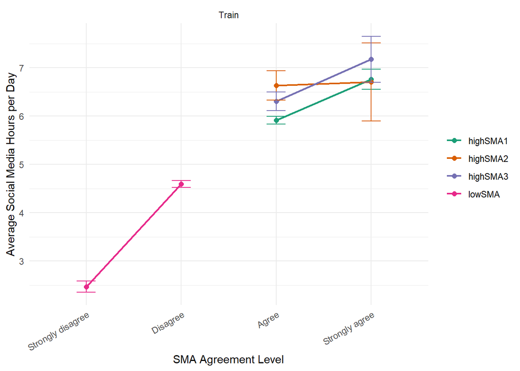

```r
ggplot(dat_train_smHrs, aes(x = sma, y = sm_hrs_Numeric, color = cluster, group = cluster)) +
  stat_summary(fun = mean, geom = "point", size = 2) +
  stat_summary(fun = mean, geom = "line", linewidth = 0.8) +
  stat_summary(fun.data = mean_se, geom = "errorbar", width = 0.2) +
  facet_wrap(~ dataset) +
  scale_y_continuous(name = "Average Social Media Hours per Day") +
  scale_x_discrete(name = "SMA Agreement Level") +
  scale_color_brewer(palette = "Dark2") +
  theme_minimal() +
  theme(
    legend.title = element_blank(),
    axis.text.x = element_text(angle = 30, hjust = 1)
  )
```

```r
Fig04b_plot <- ggplot(dat_test_smHrs, aes(x = sma, y = sm_hrs_Numeric, color = cluster, group = cluster)) +
  stat_summary(fun = mean, geom = "point", size = 2) +
  stat_summary(fun = mean, geom = "line", linewidth = 0.8) +
  stat_summary(fun.data = mean_se, geom = "errorbar", width = 0.2) +
  facet_wrap(~ dataset) +
  scale_y_continuous(name = "Average Social Media Hours per Day") +
  scale_x_discrete(name = "SMA Agreement Level") +
  theme_minimal() +
  scale_colour_manual(
    values = c(
      "highSMA1" = "#B34CC2",
      "highSMA2" = "#6BCB3D",
      "highSMA3" = "#F4A300"
    )
  ) +
  theme(
    legend.position = "none"   # removes the legend completely
  )


ggsave("figures/Fig04b.pdf", plot = Fig04b_plot, bg = "white", width = 7, height = 4.5, units = "in")
####################################################################
#### Now do stats.
####################################################################

# Compute Kendall's tau for each cluster
kendall_results <- dat_test_smHrs %>%
  group_by(cluster) %>%
  summarise(
    kendall_test = list(cor.test(as.numeric(sma), sm_hrs_Numeric, method = "kendall")),
        n = n(),
    .groups = "drop"
  ) %>%
  mutate(
    tau     = map_dbl(kendall_test, ~ .x$estimate),
    p_value = map_dbl(kendall_test, ~ .x$p.value)
  )

kendall_results
```

```
## # A tibble: 4 × 5
##   cluster  kendall_test     n    tau  p_value
##   <chr>    <list>       <int>  <dbl>    <dbl>
## 1 highSMA1 <htest>        955 0.119  2.24e- 4
## 2 highSMA2 <htest>        126 0.257  1.53e- 2
## 3 highSMA3 <htest>        211 0.0442 5.41e- 1
## 4 lowSMA   <htest>       1408 0.325  2.71e-41
```

```r
kendall_results$pearson_r <- sin((pi* kendall_results$tau)/2 )
kendall_results$z         <- correlation::z_fisher(kendall_results$pearson_r)

compare_kendall_clusters <- function(kendall_results, cluster1, cluster2) {

  z1 <- filter(kendall_results, cluster == cluster1)$z
  z2 <- filter(kendall_results, cluster == cluster2)$z

  n1 <- filter(kendall_results, cluster == cluster1)$n
  n2 <- filter(kendall_results, cluster == cluster2)$n

  # Standard error of the difference
  se_diff <- sqrt(1 / (n1 - 3) + 1 / (n2 - 3))

  # Z-score for the difference
  z_score <- (z1 - z2) / se_diff

  # P-value for a two-tailed test
  p_value <- 2 * pnorm(-abs(z_score))

  p_Bonf <- p_value*6

  # Print results
  cat("\n")
  cat(cluster1, "vs", cluster2, "\n")
  cat("Z-score:", z_score, "\n")
  cat("P-value:", p_value, "\n")
  cat("P-Bonf:", p_Bonf, "\n")


  # Return values invisibly if needed later
  invisible(list(
    comparison = paste(cluster1, "vs", cluster2),
    z_score = z_score,
    p_value = p_value,
    p_Bonf  = p_Bonf

  ))
}

compare_kendall_clusters(kendall_results, "highSMA1", "highSMA2")
```

```
##
## highSMA1 vs highSMA2
## Z-score: -2.371147
## P-value: 0.01773295
## P-Bonf: 0.1063977
```

```r
compare_kendall_clusters(kendall_results, "highSMA1", "highSMA3")
```

```
##
## highSMA1 vs highSMA3
## Z-score: 1.544384
## P-value: 0.1224954
## P-Bonf: 0.7349722
```

```r
compare_kendall_clusters(kendall_results, "highSMA2", "highSMA3")
```

```
##
## highSMA2 vs highSMA3
## Z-score: 3.036598
## P-value: 0.00239264
## P-Bonf: 0.01435584
```

```r
compare_kendall_clusters(kendall_results, "highSMA1", "lowSMA")
```

```
##
## highSMA1 vs lowSMA
## Z-score: -8.267153
## P-value: 1.371963e-16
## P-Bonf: 8.231778e-16
```

```r
compare_kendall_clusters(kendall_results, "highSMA2", "lowSMA")
```

```
##
## highSMA2 vs lowSMA
## Z-score: -1.274562
## P-value: 0.2024643
## P-Bonf: 1.214786
```

```r
compare_kendall_clusters(kendall_results, "highSMA3", "lowSMA")
```

```
##
## highSMA3 vs lowSMA
## Z-score: -6.262296
## P-value: 3.793497e-10
## P-Bonf: 2.276098e-09
```

Figure 4c and d: Comparing depression and self control.

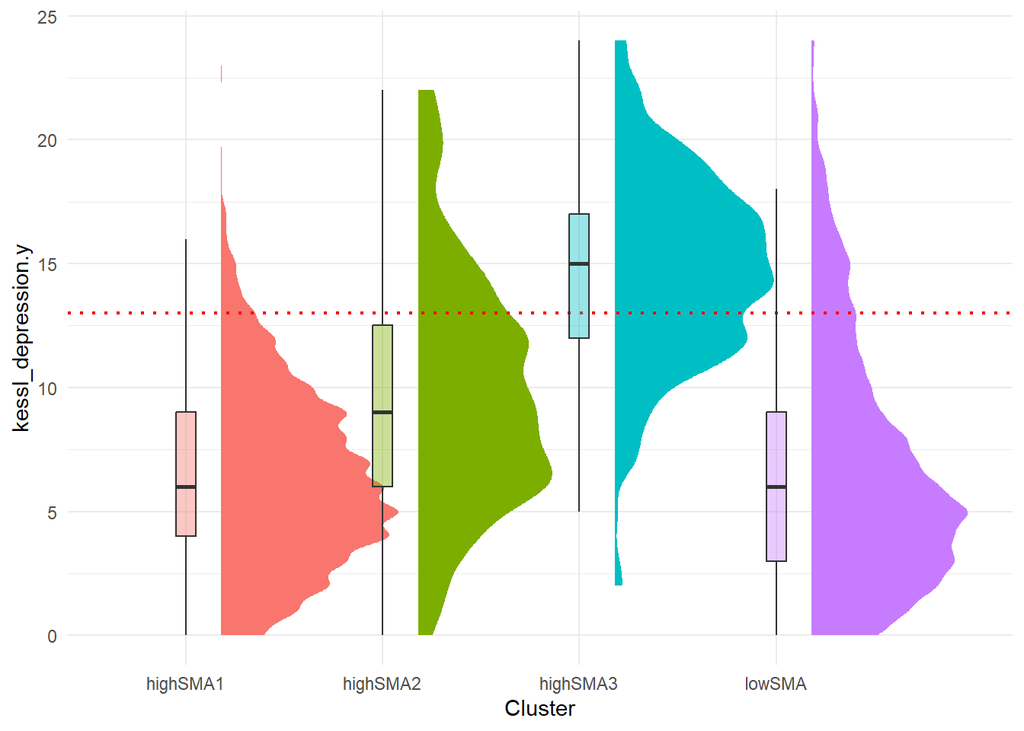

```r
ggplot(dat_train_smHrs, aes(x = as.factor(cluster), y = kessl_depression.y, fill = as.factor(cluster))) +
  ggdist::stat_halfeye(adjust = 0.6, justification = -0.2, .width = 0, point_colour = NA) +  # density cloud
 # gghalves::geom_half_point(side = "l", alpha = 0.6, shape = 21, size = 1.5, color = "black") + # jittered dots
  geom_hline(yintercept = 13, linetype = "dotted", color = "red", linewidth = 0.8) + # cutoff line
  geom_boxplot(width = 0.1, outlier.shape = NA, alpha = 0.4) +  # boxplot
  scale_x_discrete(name = "Cluster") +
  theme_minimal() +
  theme(legend.position = "none")
```

```r
Fig04c_plot <- ggplot(dat_test_smHrs, aes(x = as.factor(cluster), y = kessl_depression.y, fill = as.factor(cluster))) +
  ggdist::stat_halfeye(adjust = 0.65, justification = -0.2, .width = 0, point_colour = NA, scale = 0.7) +  # density cloud
  geom_hline(yintercept = 13, linetype = "dotted", color = "red", linewidth = 0.8) + # cutoff line
  annotate("text", x = 5.2, y = 13.3, label = "Clinical cutoff", color = "red", hjust = 0) + # label
  geom_boxplot(width = 0.1, outlier.shape = NA, alpha = 0.4) +  # boxplot
  scale_x_discrete(name = "Cluster") +
  scale_fill_manual(
    values = c(
      "highSMA1" = "#B34CC2",
      "highSMA2" = "#6BCB3D",
      "highSMA3" = "#F4A300"
    )
  ) +
  theme_minimal() +
  theme(legend.position = "none")

Fig04d_plot <- ggplot(dat_test_smHrs, aes(x = as.factor(cluster), y = self_control.y, fill = as.factor(cluster))) +
  ggdist::stat_halfeye(adjust = 0.65, justification = -0.2, .width = 0, point_colour = NA, scale = 0.7) +  # density cloud
  annotate("text", x = 5.2, y = 13.3, label = "Clinical cutoff", color = "red", hjust = 0) + # label
  geom_boxplot(width = 0.1, outlier.shape = NA, alpha = 0.4) +  # boxplot
  scale_x_discrete(name = "Cluster") +
  scale_fill_manual(
    values = c(
      "highSMA1" = "#B34CC2",
      "highSMA2" = "#6BCB3D",
      "highSMA3" = "#F4A300"
    )
  ) +
  theme_minimal() +
  theme(legend.position = "none")


ggsave("figures/Fig04c.pdf", plot = Fig04c_plot, bg = "white", width = 7, height = 4.5, units = "in")
ggsave("figures/Fig04d.pdf", plot = Fig04d_plot, bg = "white", width = 7, height = 4.5, units = "in")
####################################################################
#### Now do stats.
####################################################################

# Pairwise comparisons for kessl_depression.y
Dep_anova <- aov(kessl_depression.y ~ cluster, data = dat_test_smHrs)
summary(Dep_anova)
```

```
##               Df Sum Sq Mean Sq F value Pr(>F)
## cluster        3  12042    4014   205.8 <2e-16 ***
## Residuals   2694  52538      20
## ---
## Signif. codes:  0 '***' 0.001 '**' 0.01 '*' 0.05 '.' 0.1 ' ' 1
## 2 observations deleted due to missingness
```

```r
# Post hoc tests:
TukeyHSD(Dep_anova)
```

```
##   Tukey multiple comparisons of means
##     95% family-wise confidence level
##
## Fit: aov(formula = kessl_depression.y ~ cluster, data = dat_test_smHrs)
##
## $cluster
##                         diff         lwr        upr     p adj
## highSMA2-highSMA1  2.6622289  1.58624348  3.7382143 0.0000000
## highSMA3-highSMA1  8.0122627  7.14871400  8.8758114 0.0000000
## lowSMA-highSMA1    0.4916335  0.01560367  0.9676633 0.0398373
## highSMA3-highSMA2  5.3500339  4.07192178  6.6281459 0.0000000
## lowSMA-highSMA2   -2.1705954 -3.22627454 -1.1149163 0.0000008
## lowSMA-highSMA3   -7.5206293 -8.35874039 -6.6825181 0.0000000
```

```r
# Get means for each profile:
emmeans(Dep_anova, pairwise ~ cluster, adjust = "bonferroni")
```

```
## $emmeans
##  cluster  emmean    SE   df lower.CL upper.CL
##  highSMA1   6.48 0.143 2694     6.20     6.76
##  highSMA2   9.14 0.393 2694     8.37     9.91
##  highSMA3  14.49 0.304 2694    13.90    15.09
##  lowSMA     6.97 0.118 2694     6.74     7.20
##
## Confidence level used: 0.95
##
## $contrasts
##  contrast            estimate    SE   df t.ratio p.value
##  highSMA1 - highSMA2   -2.662 0.419 2694  -6.360  <.0001
##  highSMA1 - highSMA3   -8.012 0.336 2694 -23.851  <.0001
##  highSMA1 - lowSMA     -0.492 0.185 2694  -2.655  0.0479
##  highSMA2 - highSMA3   -5.350 0.497 2694 -10.760  <.0001
##  highSMA2 - lowSMA      2.171 0.411 2694   5.286  <.0001
##  highSMA3 - lowSMA      7.521 0.326 2694  23.067  <.0001
##
## P value adjustment: bonferroni method for 6 tests
```

```r
# Pairwise comparisons for self_control.y
SC_anova <- aov(self_control.y ~ cluster, data = dat_test_smHrs)
summary(SC_anova)
```

```
##               Df Sum Sq Mean Sq F value Pr(>F)
## cluster        3   2118   706.1   77.64 <2e-16 ***
## Residuals   2676  24338     9.1
## ---
## Signif. codes:  0 '***' 0.001 '**' 0.01 '*' 0.05 '.' 0.1 ' ' 1
## 20 observations deleted due to missingness
```

```r
# Post hoc tests:
TukeyHSD(SC_anova)
```

```
##   Tukey multiple comparisons of means
##     95% family-wise confidence level
##
## Fit: aov(formula = self_control.y ~ cluster, data = dat_test_smHrs)
##
## $cluster
##                         diff        lwr        upr     p adj
## highSMA2-highSMA1 -2.1407798 -2.8784376 -1.4031220 0.0000000
## highSMA3-highSMA1 -2.1957561 -2.7858153 -1.6056969 0.0000000
## lowSMA-highSMA1    0.6190769  0.2928652  0.9452885 0.0000067
## highSMA3-highSMA2 -0.0549763 -0.9299889  0.8200363 0.9985010
## lowSMA-highSMA2    2.7598566  2.0360533  3.4836600 0.0000000
## lowSMA-highSMA3    2.8148329  2.2421881  3.3874778 0.0000000
```

```r
# Get means for each profile:
emmeans(SC_anova, pairwise ~ cluster, adjust = "bonferroni")
```

```
## $emmeans
##  cluster  emmean     SE   df lower.CL upper.CL
##  highSMA1   12.7 0.0979 2676     12.5     12.9
##  highSMA2   10.6 0.2697 2676     10.1     11.1
##  highSMA3   10.5 0.2076 2676     10.1     11.0
##  lowSMA     13.4 0.0807 2676     13.2     13.5
##
## Confidence level used: 0.95
##
## $contrasts
##  contrast            estimate    SE   df t.ratio p.value
##  highSMA1 - highSMA2    2.141 0.287 2676   7.460  <.0001
##  highSMA1 - highSMA3    2.196 0.230 2676   9.566  <.0001
##  highSMA1 - lowSMA     -0.619 0.127 2676  -4.879  <.0001
##  highSMA2 - highSMA3    0.055 0.340 2676   0.162  1.0000
##  highSMA2 - lowSMA     -2.760 0.282 2676  -9.802  <.0001
##  highSMA3 - lowSMA     -2.815 0.223 2676 -12.636  <.0001
##
## P value adjustment: bonferroni method for 6 tests
```